# Taller_maftools

Evelin Gonzalez

2026-02-09

## Introducción a Maftools

El paquete maftools está diseñado para analizar y visualizar datos de mutaciones somáticas en archivos en formato MAF (Mutation Annotation Format). Este taller guiará a los participantes a través de los pasos básicos para cargar datos, generar resúmenes y realizar visualizaciones informativas.

### Objetivos del Taller

- Aprender a cargar archivos en formato MAF utilizando datos TCGA.
- Explorar resúmenes de variantes somáticas por muestra y por gen.
- Exportar resultados clave para informes adicionales.

```r
#install.packages("R.utils")  # solo la primera vez
library(maftools)

# MAF público (ejemplo incluido en maftools: TCGA LAML)
maf_path <- system.file("extdata", "tcga_laml.maf.gz", package = "maftools")
clin_path <- system.file("extdata", "tcga_laml_annot.tsv", package = "maftools")

clinical <- read.delim(clin_path, stringsAsFactors = FALSE)
laml <- read.maf(maf = maf_path, clinicalData = clinical)
```

```
## -Reading
## -Validating
## -Silent variants: 475
## -Summarizing
## -Processing clinical data
## -Finished in 0.128s elapsed (0.108s cpu)
```

```r
laml
```

```
## An object of class  MAF
##                    ID          summary  Mean Median
##                <char>           <char> <num>  <num>
##  1:        NCBI_Build               37    NA     NA
##  2:            Center genome.wustl.edu    NA     NA
##  3:           Samples              193    NA     NA
##  4:            nGenes             1241    NA     NA
##  5:   Frame_Shift_Del               52 0.269      0
##  6:   Frame_Shift_Ins               91 0.472      0
##  7:      In_Frame_Del               10 0.052      0
##  8:      In_Frame_Ins               42 0.218      0
##  9: Missense_Mutation             1342 6.953      7
## 10: Nonsense_Mutation              103 0.534      0
## 11:       Splice_Site               92 0.477      0
## 12:             total             1732 8.974      9
```

### Función: getSampleSummary

La función getSampleSummary proporciona un resumen de las variantes detectadas por cada muestra.

```r
#Shows sample summry.
getSampleSummary(laml)
```

```
##      Tumor_Sample_Barcode Frame_Shift_Del Frame_Shift_Ins In_Frame_Del
##                    <fctr>           <int>           <int>        <int>
##   1:         TCGA-AB-3009               0               5            0
##   2:         TCGA-AB-2807               1               0            1
##   3:         TCGA-AB-2959               0               0            0
##   4:         TCGA-AB-3002               0               0            0
##   5:         TCGA-AB-2849               0               1            0
##  ---
## 189:         TCGA-AB-2942               0               0            0
## 190:         TCGA-AB-2946               0               0            0
## 191:         TCGA-AB-2954               0               0            0
## 192:         TCGA-AB-2982               0               0            0
## 193:         TCGA-AB-2903               0               0            0
##      In_Frame_Ins Missense_Mutation Nonsense_Mutation Splice_Site total
##             <int>             <int>             <int>       <int> <num>
##   1:            1                25                 2           1    34
##   2:            0                16                 3           4    25
##   3:            0                22                 0           1    23
##   4:            0                15                 1           5    21
##   5:            0                16                 1           2    20
##  ---
## 189:            1                 0                 0           0     1
## 190:            0                 1                 0           0     1
## 191:            0                 1                 0           0     1
## 192:            0                 1                 0           0     1
## 193:            0                 0                 0           0     0
```

### Función: getGeneSummary

La función getGeneSummary detalla la frecuencia de mutaciones en cada gen dentro del conjunto de datos.

```r
#Shows gene summary.
getGeneSummary(laml)
```

```
##       Hugo_Symbol Frame_Shift_Del Frame_Shift_Ins In_Frame_Del In_Frame_Ins
##            <char>           <int>           <int>        <int>        <int>
##    1:        FLT3               0               0            1           33
##    2:      DNMT3A               4               0            0            0
##    3:        NPM1               0              33            0            0
##    4:        IDH2               0               0            0            0
##    5:        IDH1               0               0            0            0
##   ---
## 1237:      ZNF689               0               0            0            0
## 1238:      ZNF75D               0               0            0            0
## 1239:      ZNF827               1               0            0            0
## 1240:       ZNF99               0               0            0            0
## 1241:        ZPBP               0               0            0            0
##       Missense_Mutation Nonsense_Mutation Splice_Site total MutatedSamples
##                   <int>             <int>       <int> <num>          <int>
```

[output cut: 24 more lines]

### Función: getClinicalData

Si el archivo MAF contiene datos clínicos asociados a las muestras, estos pueden visualizarse con getClinicalData.

```r
#shows clinical data associated with samples
getClinicalData(laml)
```

```
##      Tumor_Sample_Barcode FAB_classification days_to_last_followup
##                    <char>             <char>                 <num>
##   1:         TCGA-AB-2802                 M4                   365
##   2:         TCGA-AB-2803                 M3                   792
##   3:         TCGA-AB-2804                 M3                  2557
##   4:         TCGA-AB-2805                 M0                   577
##   5:         TCGA-AB-2806                 M1                   945
##  ---
## 189:         TCGA-AB-3007                 M3                  1581
## 190:         TCGA-AB-3008                 M1                   822
## 191:         TCGA-AB-3009                 M4                   577
## 192:         TCGA-AB-3011                 M1                  1885
## 193:         TCGA-AB-3012                 M3                  1887
##      Overall_Survival_Status
##                        <int>
##   1:                       1
##   2:                       1
##   3:                       0
##   4:                       1
##   5:                       1
##  ---
## 189:                       0
## 190:                       1
## 191:                       1
## 192:                       0
## 193:                       0
```

### Función: getFields

Para explorar todos los campos disponibles en el archivo MAF, se utiliza la función getFields

```r
#Shows all fields in MAF
getFields(laml)
```

```
##  [1] "Hugo_Symbol"            "Entrez_Gene_Id"         "Center"
##  [4] "NCBI_Build"             "Chromosome"             "Start_Position"
##  [7] "End_Position"           "Strand"                 "Variant_Classification"
## [10] "Variant_Type"           "Reference_Allele"       "Tumor_Seq_Allele1"
## [13] "Tumor_Seq_Allele2"      "Tumor_Sample_Barcode"   "Protein_Change"
## [16] "i_TumorVAF_WU"          "i_transcript_name"
```

### Función: write.mafSummary

La función write.mafSummary permite guardar los resúmenes generados en archivos externos.

```r
#Writes maf summary to an output file with basename laml.
write.mafSummary(maf = laml, basename = 'laml')
```

### Función: plotProtein

```
## 5 transcripts available. Use arguments refSeqID or proteinID to manually specify tx name.
```

```
##      HGNC refseq.ID protein.ID aa.length
##    <char>    <char>     <char>     <num>
## 1:  BRCA1 NM_007294  NP_009225      1863
## 2:  BRCA1 NM_007297  NP_009228      1816
## 3:  BRCA1 NM_007298  NP_009229       759
## 4:  BRCA1 NM_007299  NP_009230       699
## 5:  BRCA1 NM_007300  NP_009231      1884
```

```
## Using longer transcript NM_007300 for now.
```

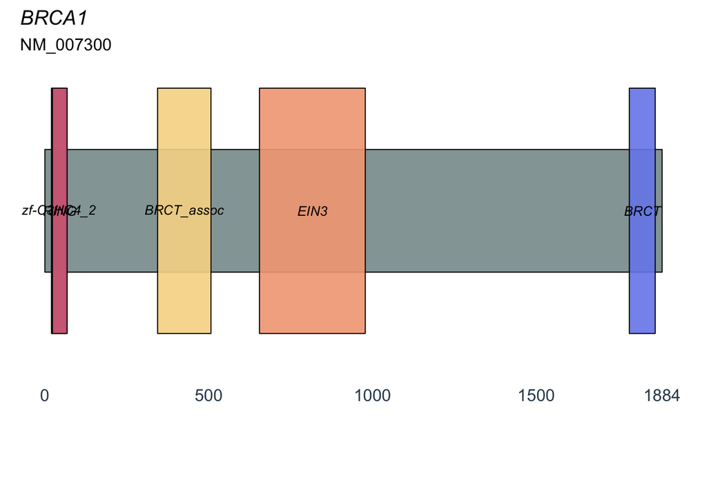

```r
plotProtein(gene = "BRCA1") #refSeqID = "NM_007300"
```

### Función: plotmafSummary

plotmafSummary genera un resumen visual de las mutaciones, como la distribución por tipo de variante.

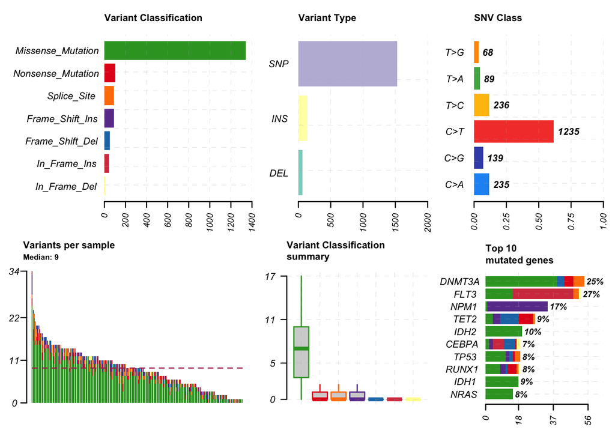

```r
plotmafSummary(maf = laml, rmOutlier = TRUE, addStat = 'median', dashboard = TRUE, titvRaw = FALSE)
```

### Función: oncoplot

Un Oncoplot muestra las mutaciones más frecuentes en los genes principales.

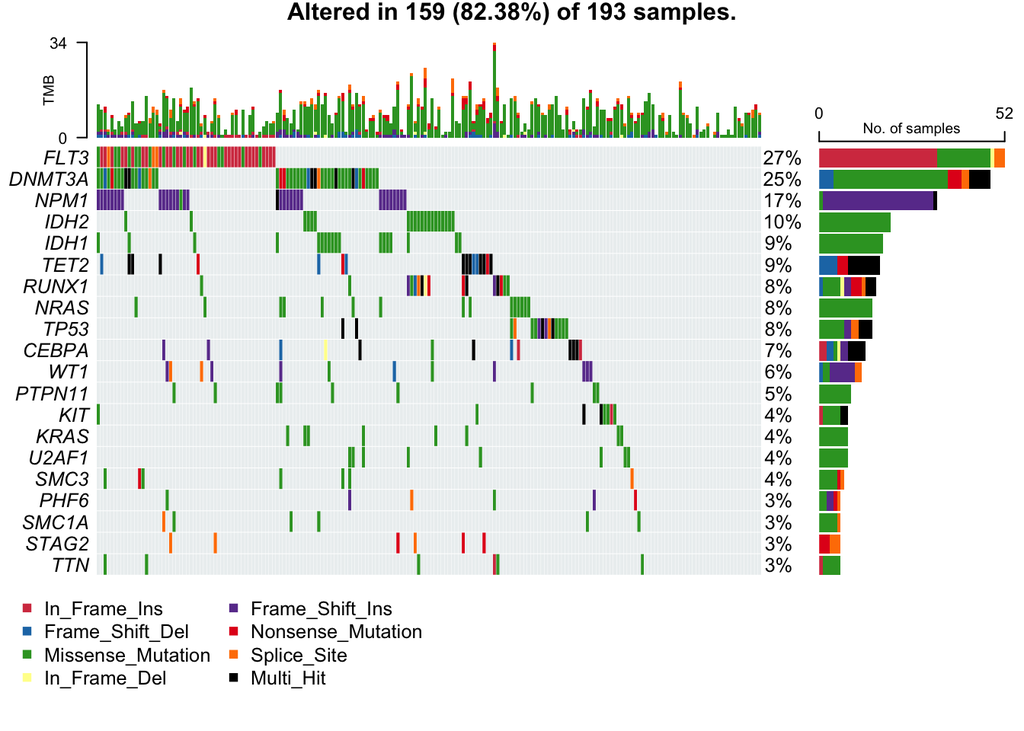

```r
oncoplot(laml)
```

```r
#oncoplot(laml, showTumorSampleBarcodes = FALSE ,SampleNamefontSize = 0.4, legendFontSize = 1.5,top = 10, drawColBar=TRUE, sortByAnnotation = TRUE)
```